# Practical: RISK PREDICTION

Advanced Statistics for Records Research

## Research question

In this session, we will explore the dataset of 2000 participants we met in the lecture, and fit a risk prediction model for death within 5 years, based on some simple patient characteristics.

## Objectives

By the end of this practical, you should be able to:

1. Fit a logistic model to create risk predictions.
2. Assess model discrimination by calculating the Area Under the Curve.
3. Assess model calibration by graphing observed and predicted risks.

## Dataset and analysis

For this practical we will use a (simulated) dataset called `data_predict`. This contains data for 2,000 patients, with information on six variables.

| Variable | Description |
| --- | --- |
| id | Unique patient ID |
| age | Age (years) |
| sbp | Systolic Blood Pressure (mm/Hg) |
| bmi | Body Max Index $kg/m^2$ |
| sex | Female / Male |
| dead | Alive / Dead |

```r
# Install Libraries
if (!require(pacman)) install.packages("pacman")
```

```r
pacman::p_load(tidyr, dplyr, ggplot2, broom, here, gtsummary)

# Load data
load(here::here("data/data_predict.rda"))
```

## Data exploration

Have a look at the data, then try answering the following participants: * How many participants died at the end of the follow-up? * What is the proportion of female participants? * What is the mean, standard deviation, minimum, and maximum age of these participants?

```r
# Base R
summary(data_predict)
```

```
#>        id              age             sbp             bmi            sex
#>  Min.   :   1.0   Min.   :40.00   Min.   : 76.6   Min.   :15.50   Female: 978
#>  1st Qu.: 500.8   1st Qu.:51.00   1st Qu.:113.7   1st Qu.:23.20   Male  :1022
#>  Median :1000.5   Median :60.00   Median :120.6   Median :25.10
#>  Mean   :1000.5   Mean   :60.45   Mean   :120.3   Mean   :25.19
#>  3rd Qu.:1500.2   3rd Qu.:70.00   3rd Qu.:127.2   3rd Qu.:27.20
#>  Max.   :2000.0   Max.   :80.00   Max.   :152.2   Max.   :35.60
#>     dead
#>  Alive:1491
#>  Dead : 509
#>
#>
#>
#>
```

```r
# Tidyverse (More verbose but more control)
data_predict %>%
  group_by(dead) %>%
  tally %>%
  mutate(percent = n/sum(n)*100)
```

```
#> # A tibble: 2 × 3
#>   dead      n percent
#>   <fct> <int>   <dbl>
#> 1 Alive  1491    74.6
#> 2 Dead    509    25.4
```

```r
data_predict %>%
  group_by(sex) %>%
  tally %>%
  mutate(percent = n/sum(n)*100)
```

```
#> # A tibble: 2 × 3
#>   sex        n percent
#>   <fct>  <int>   <dbl>
#> 1 Female   978    48.9
#> 2 Male    1022    51.1
```

```r
data_predict %>%
  # filter out missing observation at any variable
  filter_all(all_vars(!is.na(.))) %>%
  summarise(n = n(),
            mean = mean(age),
            sd = sd(age),
            min = min(age),
            max = max(age))
```

```
#> # A tibble: 1 × 5
#>       n  mean    sd   min   max
#>   <int> <dbl> <dbl> <dbl> <dbl>
#> 1  2000  60.5  11.5    40    80
```

```r
# or with gtsummary
# https://www.danieldsjoberg.com/gtsummary/index.html
tbl_summary(data_predict)
```

[output not shown]

<sup>1</sup> Median (IQR); n (%)

About 25% of the 2,000 individuals die – this is a high-risk population. There is roughly 50% males and 50% females, aged 40-80.

### Randomly split data into training and test sets

```r
set.seed(777)

n_total <- nrow(data_predict)
proportion_train <- 0.5
n_train <- floor(proportion_train * n_total)

sample_train <- sample(1:n_total, n_train) %>% sort
sample_test <- which(!(1:n_total %in% sample_train))

data_train <- data_predict[sample_train,]
data_test <- data_predict[sample_test,]
```

### Fit model in training data

```r
# Fit logistic regression
model <- glm(formula = dead ~ age + sex + sbp + bmi,
             family = "binomial",
             data = data_train)

# View model output summary
summary(model)
```

```
#>
#> Call:
#> glm(formula = dead ~ age + sex + sbp + bmi, family = "binomial",
#>     data = data_train)
#>
#> Deviance Residuals:
#>     Min       1Q   Median       3Q      Max
#> -1.9187  -0.7526  -0.4669   0.6399   2.7754
#>
#> Coefficients:
#>               Estimate Std. Error z value Pr(>|z|)
#> (Intercept) -13.297927   1.440507  -9.231  < 2e-16 ***
#> age           0.086203   0.007921  10.883  < 2e-16 ***
#> sexMale       0.155126   0.160836   0.965    0.335
#> sbp           0.052679   0.008465   6.223 4.87e-10 ***
#> bmi           0.013306   0.027782   0.479    0.632
#> ---
#> Signif. codes:  0 '***' 0.001 '**' 0.01 '*' 0.05 '.' 0.1 ' ' 1
#>
#> (Dispersion parameter for binomial family taken to be 1)
#>
#>     Null deviance: 1126.86  on 999  degrees of freedom
#> Residual deviance:  950.39  on 995  degrees of freedom
#> AIC: 960.39
#>
#> Number of Fisher Scoring iterations: 5
```

```r
# Get odds ratio and 95% CI
cbind(OR = coef(model), confint(model)) %>% exp
```

```
#>                       OR        2.5 %       97.5 %
#> (Intercept) 1.677968e-06 9.341761e-08 2.662586e-05
#> age         1.090028e+00 1.073596e+00 1.107490e+00
#> sexMale     1.167805e+00 8.524485e-01 1.602203e+00
#> sbp         1.054091e+00 1.037001e+00 1.072023e+00
#> bmi         1.013395e+00 9.596049e-01 1.070147e+00
```

```r
# tidy method
tidy(model)
```

```
#> # A tibble: 5 × 5
#>   term        estimate std.error statistic  p.value
#>   <chr>          <dbl>     <dbl>     <dbl>    <dbl>
#> 1 (Intercept) -13.3      1.44       -9.23  2.67e-20
#> 2 age           0.0862   0.00792    10.9   1.39e-27
#> 3 sexMale       0.155    0.161       0.965 3.35e- 1
#> 4 sbp           0.0527   0.00846     6.22  4.87e-10
#> 5 bmi           0.0133   0.0278      0.479 6.32e- 1
```

### Predict risk based on trained model

#### On training dataset

```r
# update data_train and data_test with predicted probabilites
data_train$prob_dead <-
  predict(model, type = "response")

# compare predicted risk
data_train %>%
  group_by(dead) %>%
  summarise(n = n (),
            mean = mean(prob_dead),
            sd = sd(prob_dead),
            min = min(prob_dead),
            max = max(prob_dead)) %>%
  pivot_longer(-dead) %>%
  pivot_wider(id_cols = name, names_from = dead)
```

```
#> # A tibble: 5 × 3
#>   name     Alive     Dead
#>   <chr>    <dbl>    <dbl>
#> 1 n     749      251
#> 2 mean    0.207    0.383
#> 3 sd      0.155    0.189
#> 4 min     0.0134   0.0213
#> 5 max     0.841    0.820
```

#### On test dataset

```r
data_test$prob_dead <-
  predict(model, type = "response", newdata = data_test)

data_test %>%
  group_by(dead) %>%
  summarise(n = n (),
            mean = mean(prob_dead),
            sd = sd(prob_dead),
            min = min(prob_dead),
            max = max(prob_dead)) %>%
  pivot_longer(-dead) %>%
  pivot_wider(id_cols = name, names_from = dead)
```

```
#> # A tibble: 5 × 3
#>   name     Alive     Dead
#>   <chr>    <dbl>    <dbl>
#> 1 n     742      258
#> 2 mean    0.212    0.406
#> 3 sd      0.160    0.192
#> 4 min     0.0149   0.0256
#> 5 max     0.850    0.844
```

```r
# Alternative solution (with broom::augment() )
alt_data_train <- model %>%
  # augment creates new columns with some useful information from the model
  # .fitted = predicted values
  augment(type.predict = "response")

alt_data_test <- model %>%
  augment(type.predict = "response", newdata = data_test)
```

### Validation

#### ROC

```r
pacman::p_load(yardstick)

# combine dataset
data_grouped <- bind_rows(data_train %>% mutate(set = "Training"),
                      data_test %>% mutate(set = "Validation")) %>%
  group_by(set)

# Calculate ROC
data_grouped %>%
  # set the second level of factor variable as the event (i.e. dead)
  roc_auc(truth = dead, prob_dead, event_level = "second")
```

```
#> # A tibble: 2 × 4
#>   set        .metric .estimator .estimate
#>   <chr>      <chr>   <chr>          <dbl>
#> 1 Training   roc_auc binary         0.767
#> 2 Validation roc_auc binary         0.783
```

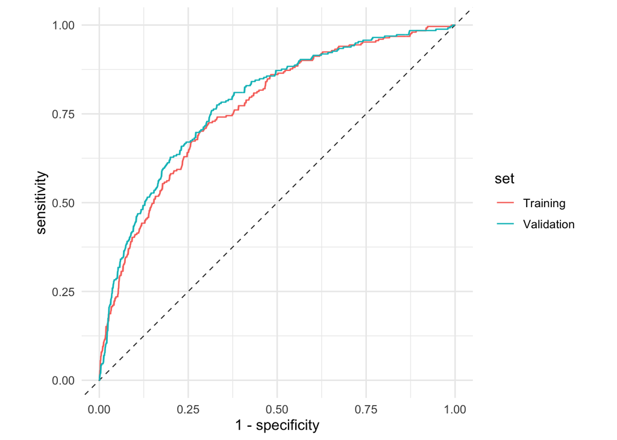

```r
# Visualise ROC
data_roc <- data_grouped %>%
  roc_curve(truth = dead, prob_dead, event_level = "second")

ggplot(data_roc, aes(x = 1-specificity, y = sensitivity, color = set)) +
  geom_abline(slope = 1, intercept = 0,
              size = 0.4, color = "grey21", linetype = "dashed") +
  geom_line() +
  theme_minimal(base_size = 12) +
  coord_equal()
```

#### Hosmer-Lemeshow

The Hosmer-Lemeshow goodness of fit table for the two (S=0 and the S=1) datasets were very similar. Both showed evidence of a well calibrated model.

```r
pacman::p_load(generalhoslem)

gof <- data_grouped %>%
  group_map( ~ logitgof(
    obs = .$dead,
    exp = .$prob_dead,
    g = 10
  ))

# Fix name
names(gof) <- group_keys(data_grouped)[[group_vars(data_grouped)]]

# output Goodness of Fit metrics
gof
```

```
#> $Training
#>
#>  Hosmer and Lemeshow test (binary model)
#>
#> data:  .$dead, .$prob_dead
#> X-squared = 8.105, df = 8, p-value = 0.4233
#>
#>
#> $Validation
#>
#>  Hosmer and Lemeshow test (binary model)
#>
#> data:  .$dead, .$prob_dead
#> X-squared = 4.7631, df = 8, p-value = 0.7826
```

```r
# create GoF table
gof_table <- lapply(gof, function(x){
  cbind(x$observed, x$expected) %>%
    as_tibble(rownames = "threshold") %>%
    mutate(group = 1:nrow(.))
})

gof_table$Training
```

```
#> # A tibble: 10 × 6
#>    threshold          y0    y1 yhat0 yhat1 group
#>    <chr>           <dbl> <dbl> <dbl> <dbl> <int>
#>  1 [0.0134,0.0541]    94     6  96.2  3.79     1
#>  2 (0.0541,0.085]     94     6  92.9  7.09     2
#>  3 (0.085,0.115]      92     8  90.0 10.0      3
#>  4 (0.115,0.153]      86    14  86.8 13.2      4
#>  5 (0.153,0.204]      77    23  82.4 17.6      5
#>  6 (0.204,0.267]      84    16  76.3 23.7      6
#>  7 (0.267,0.337]      68    32  69.8 30.2      7
#>  8 (0.337,0.415]      65    35  62.9 37.1      8
#>  9 (0.415,0.522]      50    50  53.4 46.6      9
#> 10 (0.522,0.841]      39    61  38.2 61.8     10
```

```r
gof_table$Validation
```

```
#> # A tibble: 10 × 6
#>    threshold          y0    y1 yhat0 yhat1 group
#>    <chr>           <dbl> <dbl> <dbl> <dbl> <int>
#>  1 [0.0149,0.0582]    95     5  95.9  4.12     1
#>  2 (0.0582,0.0897]    94     6  92.6  7.43     2
#>  3 (0.0897,0.121]     90    10  89.5 10.5      3
#>  4 (0.121,0.161]      88    12  86.0 14.0      4
#>  5 (0.161,0.208]      84    16  81.6 18.4      5
#>  6 (0.208,0.274]      74    26  76.2 23.8      6
#>  7 (0.274,0.35]       75    25  69.0 31.0      7
#>  8 (0.35,0.437]       62    38  60.3 39.7      8
#>  9 (0.437,0.547]      50    50  50.9 49.1      9
#> 10 (0.547,0.85]       30    70  35.8 64.2     10
```

Bar graphs comparing the predicted and observed risks in the S=0 and S=1 datasets also show good calibration (in both the training and validation data).

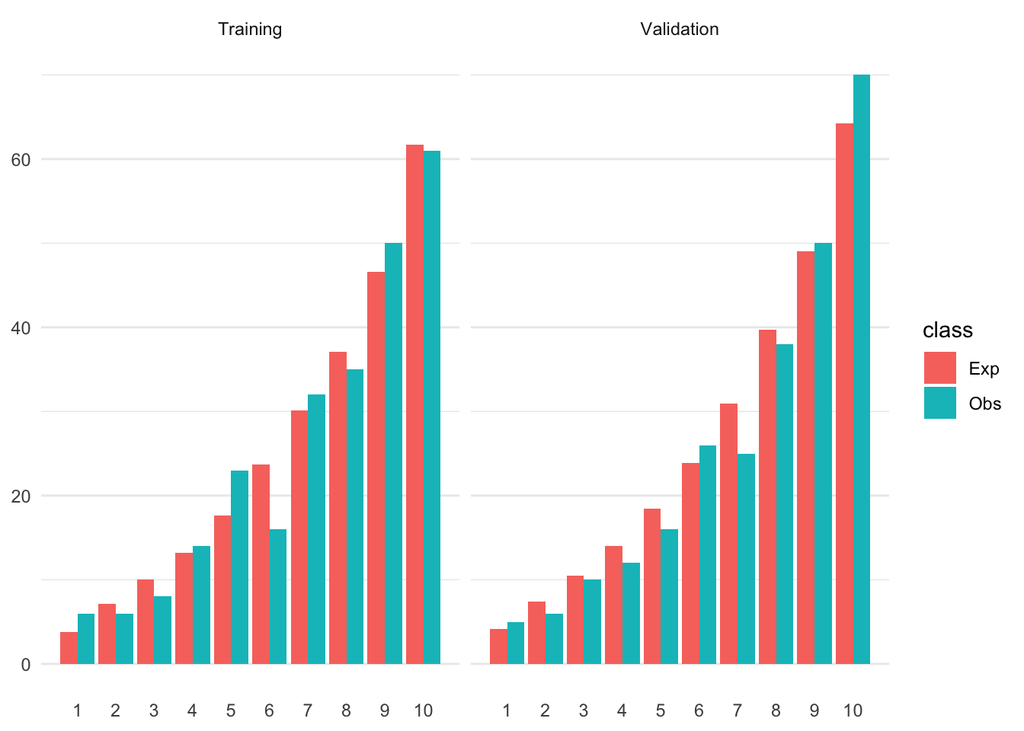

```r
# tidy up gof_table for plotting
tidy_gof <- bind_rows(gof_table, .id = "set") %>%
  dplyr::select(set, group, Obs = y1, Exp = yhat1) %>%
  pivot_longer(
    cols = c(Obs, Exp),
    names_to = "class"
  )

# plotting
tidy_gof %>%
  ggplot(aes(x = group, y = value, fill = class)) +
  facet_grid(cols = vars(set)) +
  geom_bar(stat = "identity", position = position_dodge()) +
  scale_x_continuous(breaks = 1:10) +
  theme_minimal() +
  theme(panel.grid.minor.x = element_blank(),
        panel.grid.major.x = element_blank(),
        axis.title = element_blank())
```

### Calibration curve

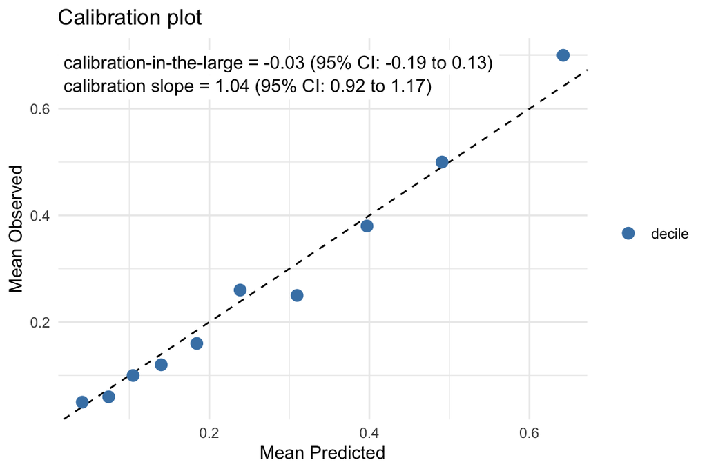

```r
df_model <- model %>%
  # augment creates new columns with some useful information from the model
  # .fitted = predicted values
  augment(type.predict = "link", newdata = data_test) %>%
  mutate(dead_count = as.numeric(dead) - 1) %>%
  arrange(.fitted)

# calculate alpha (calibration at large) & beta (calibration slope)
# alpha is calculated by constraining beta to 1

df_alpha <- glm(dead_count ~ offset(.fitted),
               data = df_model,
               family = binomial) %>%
  tidy(conf.int = TRUE)

alpha_text <- paste0(round(df_alpha$estimate[1], 2),
                     " (95% CI: ", round(df_alpha$conf.low[1], 2),
                     " to ", round(df_alpha$conf.high[1], 2),
                     ")")

# beta is calculated by constraining alpha to 0
df_beta <- glm(dead_count ~ .fitted - 1,
                data = df_model,
                family = binomial) %>%
  tidy(conf.int = TRUE)

beta_text <- paste0(round(df_beta$estimate[1], 2),
                    " (95% CI: ", round(df_beta$conf.low[1], 2),
                    " to ", round(df_beta$conf.high[1], 2),
                    ")")


# calculate mean predicted results per decile
df_sum_decile <- model %>%
  # augment creates new columns with some useful information from the model
  # .fitted = predicted values
  augment(type.predict = "response", newdata = data_test) %>%
  mutate(dead_count = as.numeric(dead) - 1) %>%
  arrange(.fitted) %>%
  mutate(decile = ntile(.fitted, 10)) %>%
  group_by(decile) %>%
  summarize(mean_prediction = mean(.fitted),
            sd_prediction = sd(.fitted),
            prop_observed = mean(dead_count)) %>%
  mutate(dummy = "decile")

# plotting
ggplot(df_sum_decile, aes(x = mean_prediction, y = prop_observed)) +
  theme_minimal() +
  geom_abline(slope = 1, intercept = 0, linetype = "dashed") +
  # geom_abline(slope = 1, intercept = df_alpha$estimate[1], color = "#1b5299") +
  geom_point(aes(color = dummy), size = 3) +
  scale_color_manual(values = "steelblue") +
  labs(x = "Mean Predicted", y = "Mean Observed", title = "Calibration plot") +
  annotate("label", x = -Inf, y = Inf, hjust = 0, vjust = 1.5, label.size = 0,
           label = paste("calibration-in-the-large =",
                         alpha_text)) +
  annotate("label", x = -Inf, y = Inf, hjust = 0, vjust = 2.5, label.size = 0,
           label = paste("calibration slope =",
                         beta_text)) +
  theme(legend.title = element_blank())
```

Since calibration-in-the-large is close to 0, and calibration slope is close to 1, we can say that the model is well calibrated